# ACHD_ADMIN

Calum Nicholson

18/06/2020

**To do** Select data for patients with correct address recorded  
Check through values for clinic_comment, what do they all mean how can we organise them? Check how removing missing data affects the demographics.

**Create a ‘Person-Level’ Dataset**

The ACHD database contains a number of tables, joined by the person identified “person_id”. These will be joined into a single person level datasat. The key tables are: - ADMIN: names, addresses, contact details, dob, sex.  
- MAIN: contains the minimum dataset, with diagnosis information and who their clincian is (i,e. DC, RC or SHC).  
- DEMOGRAPHICS: This contains basic demographics information. A lot of this table in incomplete, however there is useful information in country of birth and indigenous status.  
- FOLLOW UP STATUS: This is a ‘clinic level’ dataset, where each record is a clinic visit, with the date of the visit and a comment about which clinic is was (i.e. which private doctor, or public clinic or outreach clinic)  
- CLINIC VISIT: Similar to the follow up table but contained more detailed info (i.e bp and heart rate). has only been collecting info for the past two years and only for DCs patients  
- DEATH: Recording deceased patients, taken from NDI data linkage.

*ADMIN*

```r
# Load ADMIN table from ACHD database
ADMIN <- read.csv(paste(ACHD_path, 'Table_exports/ADMIN.csv', sep="")) %>%
#         ------------Clean up the data-------------------------
          # select columns
          dplyr::select(person_id, adm_sex, adm_date_of_birth,
                 adm_suburb_locality, adm_postcode, adm_state_abbreviation) %>%
          # rename columns
          rename('achd_id' = person_id,
                 'sex' = adm_sex,
                 'dob' = adm_date_of_birth,
                 'suburb' = adm_suburb_locality,
                 'postcode' = adm_postcode,
                 'state' = adm_state_abbreviation) %>%
          # remove timestamp from visit date
          mutate_at("dob", str_remove, pattern = " 0:00:00") %>%
          # Convert clinic dates to Date format
          mutate_at("dob", as.Date, format='%d/%m/%Y') %>%
          # Calculate age on 01 Jan 2020
          mutate(age = as.period(dob %--% as.Date("01/01/2020", format='%d/%m/%Y'))) %>%
          # Flag for ages greater than 18 years old
          mutate(age_flag = ifelse(as.numeric(age, "years") >= 18, 1, 0)) %>%
          # Remove whitespace from suburb name
          mutate_at("suburb", str_trim, side = "both") %>%
          # Change all suburbs to uppercase
          mutate_at("suburb", str_to_upper, locale = "en") %>%
          # Convert suburb from to character format
          mutate_at("suburb", as.character) %>%
          # Convert postcode to character format
          mutate_at("postcode", as.character)
```

**Selecting for records with valid addresses**

Check the dataset for missing postcodes, states, overseas or interstate addresses. a few of the records have some missing data but we can safely infer what the missing information is and fix them up:  
- achd_id 910 has subrub of CLAREVILLE, but is missing the postcode, CLAREVILLE only matches to one SA2 area in the lookup table so we can safely assume the postcode is the same as the lookup table: 2107  
- achd_ids 11, 1385, 2792m, 2034 4023, 4732, 4883, 4892 the state field missing, but the postcode and suburb are in NSW, so we can add the state as NSW

```r
ADMIN <- ADMIN %>%
                mutate(
                  postcode = replace(postcode, achd_id == 910, 2107),
                  state = replace(state, achd_id == 4732, "NSW"),
                  state = replace(state, achd_id == 4883, "NSW"),
                  state = replace(state, achd_id == 4892, "NSW"),
                  state = replace(state, achd_id == 1385, "NSW"),
                  state = replace(state, achd_id == 2792, "NSW"),
                  state = replace(state, achd_id == 2034, "NSW"),
                  state = replace(state, achd_id == 11, "NSW"),
                  state = replace(state, achd_id == 4023, "NSW"),
                       ) %>%
                mutate(
                  valid_address = ifelse( ( suburb != "" & suburb != "OVERSEAS" & suburb != "-") &
                                            (postcode != "" & !is.na(postcode)) &
                                            ( state == "NSW" | state == "ACT"), 1, 0)
                       )
```

**Cleaning Addresses**

The addresses above have some typos, they will be cross references with the sa2 lookup table, first checking the suburb, then the postcode to see if an obvious typo can be identified. If there is no reasonable solution, the record will be marked as an invalid address

```r
ADMIN <- ADMIN %>%
                mutate(
                  postcode = replace(postcode, achd_id == 4688, 2112),
                  suburb = replace(suburb, achd_id == 4675, 'SYDNEY'),
                  postcode = replace(postcode, achd_id == 327, 2203),
                  valid_address = replace(valid_address, achd_id == 3360, 0),
                  postcode = replace(postcode, achd_id == 2672, 2006),
                  postcode = replace(postcode, achd_id == 2065, 2047),
                  postcode = replace(postcode, achd_id == 2120, 2046),
                  postcode = replace(postcode, achd_id == 1361, 2006),
                  postcode = replace(postcode, achd_id == 34, 2045),
                  postcode = replace(postcode, achd_id == 2524, 2198),
                  suburb = replace(suburb, achd_id == 4107, 'DULWICH HILL'),
                  postcode = replace(postcode, achd_id == 444, 2066),
                  suburb = replace(suburb, achd_id == 2382, 'TORONTO'),
                  suburb = replace(suburb, achd_id == 156, 'MOUNT KURING-GAI'),
                  postcode = replace(postcode, achd_id == 256, 2017),
                  suburb = replace(suburb, achd_id == 406, 'NORTH ENTRANCE BEACH'),
                  postcode = replace(postcode, achd_id == 81, 2049),
                  suburb = replace(suburb, achd_id == 275, 'JAMISON CENTRE'),
                  postcode = replace(postcode, achd_id == 1259, 2615),
                  suburb = replace(suburb, achd_id == 4894, 'HELENSBURGH'),
                  suburb = replace(suburb, achd_id == 78, 'ROBERTSON'),
                  postcode = replace(postcode, achd_id == 1583, 2193),
                  suburb = replace(suburb, achd_id == 2695, 'SYLVANIA'),
                  suburb = replace(suburb, achd_id == 2639, 'WAVERLY'),
                  valid_address = replace(valid_address, achd_id == 2302, 0),
                  postcode = replace(postcode, achd_id == 2019, 2478),
                  postcode = replace(postcode, achd_id == 2871, 2040),
                  postcode = replace(postcode, achd_id == 2388, 2006),
                  postcode = replace(postcode, achd_id == 1973, 2006),
                  postcode = replace(postcode, achd_id == 254, 2006),
                  suburb = replace(suburb, achd_id == 1445, 'FIVE DOCK'),
                  suburb = replace(suburb, achd_id == 4995, 'NORTHBRIDGE'),
                  valid_address = replace(valid_address, achd_id == 906, 0),
                  valid_address = replace(valid_address, achd_id == 4337, 0),
                  valid_address = replace(valid_address, achd_id == 539, 0),
                  suburb = replace(suburb, achd_id == 911, 'TRUNDLE'),
                  postcode = replace(postcode, achd_id == 4001, 2825),
                  suburb = replace(suburb, achd_id == 5054, 'BERKELEY VALE'),
                  suburb = replace(suburb, achd_id == 5042, 'DUBBO'),
                  suburb = replace(suburb, achd_id == 1861, 'CROYDON'),
                  postcode = replace(postcode, achd_id == 26, 2137),
                  postcode = replace(postcode, achd_id == 4237, 2585),
                  postcode = replace(postcode, achd_id == 318, 2006),
                  postcode = replace(postcode, achd_id == 1094, 2204),
                  suburb = replace(suburb, achd_id == 4545, 'GREEN VALLEY'),
                  postcode = replace(postcode, achd_id == 3691, 2006),
                  valid_address = replace(valid_address, achd_id == 4585, 0),
                  postcode = replace(postcode, achd_id == 3390, 2261),
                  postcode = replace(postcode, achd_id == 4272, 2212),
                  postcode = replace(postcode, achd_id == 4623, 2166),
                  valid_address = replace(valid_address, achd_id == 2514, 0),
                  postcode = replace(postcode, achd_id == 2419, 2617)
                  # up to achd_id 910
                )
```

*MAIN*

```r
# Load the MAIN table from the ACHD database
MAIN <- read.csv(paste(ACHD_path, 'Table_exports/main_Table.csv', sep=""))  %>%
#       ------------Clean up the data-------------------------
        select(person_id, SHC, DC, adm_RC, adm_Bethesda, adm_Bethesda_Code, FupStatus, Death_Cause,
               ABNAO, AbnAV, AbnMV, ABNPV, AbnRV, ABNTV, adm_AbnCA, adm_AbnVeins, adm_AbsentPA, adm_ALCAPA,
               adm_Aneurism, adm_APwindow, adm_AVfistula, adm_CHB, adm_CorTriatriatum, adm_Gerbodde,
               adm_Hemi_truncus,adm_LPA_sling, adm_PAV_Malform, adm_Shones, AoC, AoInterrupt, AR, AS, ASD,
               AVSD, BAVD, ccTGA, DEXTROCARDIA, DILV, DIRV, DORV, Ebsteins, EISENMENGERS, FONTAN, HLHS,
               LVNONCOMPACT, MAPCAs, Other, PA, PAPVD, PAS, PDA, PFO, PS, SubAS, SubPS, SupraAS, SupraMS,
               SupraPS, TA, TAPVD, TGA, TOF, TRUNCART, UnkDx, VSD, achd.1) %>%
        rename('achd_id' = person_id,
               'dx_comment' = achd.1,
               'RC' = adm_RC,
               'bethesda_name' = adm_Bethesda,
               'bethesda_code' = adm_Bethesda_Code,
               'death' = FupStatus,
               'AbnCA' = adm_AbnCA,
               'AbnVeins' = adm_AbnVeins,
               'AbsentPA' = adm_AbsentPA,
               'ALCAPA' = adm_ALCAPA,
               'Aneurism' = adm_Aneurism,
               'APwindow' = adm_APwindow,
               'AVfistula' = adm_AVfistula,
               'CHB' = adm_CHB,
               'CorTriatriatum' = adm_CorTriatriatum,
               'Gerbodde' = adm_Gerbodde,
               'Hemi_truncus' = adm_Hemi_truncus,
               'LPA_sling' = adm_LPA_sling,
               'PAV_Malform' = adm_PAV_Malform,
               'Shones' = adm_Shones,
               'Ebstein' = Ebsteins,
               'EISENMENGER' = EISENMENGERS,
               'MAPCA' = MAPCAs)
```

All of the diagnosis variables code 1 or -1 for true and 0 or NA for untrue. To make it a little easier to read, we will recode -1 to 1 and NA to 0.

The death variable (FupStatus) also codes alive as NA or 0, recode all NA’s to 0

```r
# all the diagnosis variables
dx_names <- c('ABNAO','AbnAV','AbnMV','ABNPV','AbnRV','ABNTV','AbnCA','AbnVeins','AbsentPA','ALCAPA', 'Aneurism',
              'APwindow','AVfistula','CHB','CorTriatriatum','Gerbodde','Hemi_truncus','LPA_sling','PAV_Malform',
              'Shones','AoC','AoInterrupt','AR','AS','ASD','AVSD','BAVD','ccTGA','DEXTROCARDIA','DILV','DIRV','DORV',
              'Ebstein','EISENMENGER','FONTAN','HLHS','LVNONCOMPACT','MAPCA','Other','PA','PAPVD','PAS','PDA','PFO',
              'PS','SubAS','SubPS','SupraAS','SupraMS','SupraPS','TA','TAPVD','TGA','TOF','TRUNCART','UnkDx','VSD')

# recode the diagnoses to binary
MAIN <- MAIN %>% mutate_at(dx_names,
                            function(x) replace(x, is.na(x), 0) # recode all na values to 0
                           ) %>%
                 mutate_at(dx_names,
                            function(x) replace(x, x == -1, 1) # recode all -1 values to 1
                           ) %>%
                 mutate_at('death',
                           function(x) replace(x, is.na(x), 0) # recode all na values to 0
                           ) %>%
                 mutate(no_dx = rowSums(.[,dx_names]))
```

in the disease severity code ‘bethesda_code’; 4 codes for ‘Classification Unknown’, there are a few other codes (0,9,NA) that can be cleaned to 4 also

```r
# recode the classification to unknown
MAIN <- MAIN %>% mutate_at('bethesda_code',
                            function(x) replace(x, (is.na(x) | x == 0 | x == 9), 4) # recode all na values to 0
                           )
```

*DEATH*

```r
# load the DEATH table from the ACHD database
DEATH <- read.csv(paste(ACHD_path, 'Table_exports/DEATH.csv', sep="")) %>%
#        ------------Clean up the data-------------------------
         # remove unnecessary columns
         select(person_id, death_date) %>%
         # remove timestamp from death date
         mutate_at("death_date", str_remove, pattern = " 0:00:00") %>%
         # convert death date to date type
         mutate_at("death_date", as.Date, format='%d/%m/%Y') %>%
         # rename columns
         rename("achd_id" = person_id)
```

*ASGS AREAS*

```r
# Import ASGS Lookup table
asgs_lookup <- read.csv("./development/EDA/output/ASGS_lookup.csv") %>%
#             ------------Clean up the data-----------------
              # select subrub, postcode and sa2 name columns
              select(LOCALITY_NAME,POSTCODE,SA2_NAME, SA3_NAME_2016, SA4_NAME_2016) %>%
              # Convert postcode to character
              mutate_at("POSTCODE", as.character) %>%
              # Convert suburb name to character
              mutate_at("LOCALITY_NAME", as.character)
```

```r
# Add the ASGS area names to the ADMIN dataset, based on the suburb and postcode name
ADMIN_sa2 <- left_join(ADMIN, asgs_lookup, by = c("suburb" = "LOCALITY_NAME",
                                                 "postcode" = "POSTCODE"))
```

*FOLLOW UP STATUS*

```r
# load Follow Up Status dataset
FUP <- read.csv(paste(ACHD_path, 'Table_exports/FOLLOW-UP STATUS.csv', sep="")) %>%
#               ------------Clean up the data-------------------------
                # select columns for id and clinic dates
                select(person_id, fup_last_date, fup_comment, fup_Seen_by, fup_outreach, fup_new) %>%
                # rename columns
                rename( 'achd_id' = person_id,
                        'clinic_date' = fup_last_date,
                        'clinic_comment' = fup_comment,
                        'seen_by' = fup_Seen_by,
                        'outreach' = fup_outreach,
                        'new' = fup_new) %>%
                # remove timestamp from clinic date
                mutate_at("clinic_date", str_remove, pattern = " 0:00:00") %>%
                # Convert clinic dates to Date format
                mutate_at("clinic_date",as.Date, format='%d/%m/%Y') %>%
                # Arrange by clinic date in ascending order
                arrange(clinic_date) %>%
                # Filter for records without a missing clinic date
                filter(!is.na(clinic_date)) %>%
                # Replace missing in "seen_by" with NA
                mutate(seen_by = replace(seen_by, seen_by == "", NA))
```

```r
# Join the tables to create a person level dataset

                # Add data from MAIN Table
person.level <- left_join(ADMIN_sa2, MAIN, by = "achd_id") %>%
                rename("sa2" = SA2_NAME,
                       "sa3" = SA3_NAME_2016,
                       "sa4" = SA4_NAME_2016) %>%
                # Add data from DEATH table
                left_join(DEATH, by = 'achd_id') %>%
                # Add 0 flag for people still alive in 'death' variable
                mutate(death = replace(death, is.na(death), 0)) %>%
                # add age at death
                mutate(age_death = as.period(dob %--% death_date)) %>%
                # add data from Follow Up Status table
                nest_join(FUP, by = 'achd_id') %>%
                rename( 'clinics' =  FUP)
```

The dataframes contained in `clinics` column looks like this (for one record):

```r
# display one of the clinic_dates dataframes
person.level %>% filter(achd_id == 1101) %>% .$clinics
```

```
## [[1]]
## # A tibble: 14 x 5
##    clinic_date clinic_comment    seen_by outreach new
##    <date>      <fct>             <fct>   <lgl>    <lgl>
##  1 2013-02-08  ECHO @ RPA        <NA>    FALSE    FALSE
##  2 2013-10-11  ECHO @ RPA        <NA>    FALSE    FALSE
##  3 2014-02-14  ECHO @ RPA        <NA>    FALSE    FALSE
##  4 2014-11-28  Dr M Halmagyi     <NA>    FALSE    FALSE
##  5 2015-03-26  Prof Ian Caterson <NA>    FALSE    FALSE
##  6 2015-05-04  SHC ACHD_DrRC_New RC      FALSE    TRUE
##  7 2015-09-18  SHC ACHD_DrRC     SHC     FALSE    FALSE
##  8 2016-05-02  SHC ACHD_DrRC     SHC     FALSE    FALSE
##  9 2016-07-08  SHC ACHD_DrRC     SHC     FALSE    FALSE
## 10 2017-05-25  SHC ACHD_DrRC     SHC     FALSE    FALSE
## 11 2017-11-10  SHC ACHD_DrRC     SHC     FALSE    FALSE
## 12 2018-05-07  SHC ACHD_DrRC     SHC     FALSE    FALSE
## 13 2018-11-05  SHC ACHD_DrRC     SHC     FALSE    FALSE
## 14 2019-06-03  SHC ACHD_DrRC     SHC     FALSE    FALSE
```

To get some more information about the clinic visits for each patient, we will pull some information out of the `clinics` column

```r
# Add some more rows to the dataset
person.level <- person.level %>%
            mutate(
              # Number of clinics for each patient
              no_clinics = map_dbl(map(clinics, ~ .$clinic_date), length),
              # First clinic date for each patient
              first_clinic = as_date(map_dbl(clinics, ~ min(.$clinic_date))),
              # Last clinic date for each patient
              last_clinic = as_date(map_dbl(clinics, ~ max(.$clinic_date))),
              # Number of days between first and last clinic
              date_diff = as.duration(first_clinic %--% last_clinic) / dyears(1),
              # age at first clinic attendance
              age_first_clinic = as.period(dob %--% first_clinic),
              # age at last clinic attendance
              age_last_clinic = as.period(dob %--% last_clinic)
               )
```

```r
person.level <- person.level %>%
            mutate(
              # Remove visits before 01/01/2000
              clinics_2000 = map(clinics, ~ filter(., clinic_date >= as.Date('01/01/2000', format='%d/%m/%Y'))),
              # number of clinics for each patient
              no_clinics_2000 = map_dbl(map(clinics_2000, ~ .$clinic_date), length),
              # Flag to for patient with no visit before 2000
              clinic_drop = ifelse(no_clinics_2000 == 0, 1, 0),
              # First clinic date for each patient
              first_clinic_2000 = as_date(map_dbl(clinics_2000, ~ min(.$clinic_date))),
              # Last clinic date for each patient
              last_clinic_2000 = as_date(map_dbl(clinics_2000, ~ max(.$clinic_date))),
              # Years between first and last clinic
              date_diff_2000 = as.duration(first_clinic_2000%--%last_clinic_2000)/dyears(1),
              # Recode infinity to NA
              date_diff_2000 = replace(date_diff_2000, date_diff_2000 == -Inf, NA),
              # age at first clinic attendance
              age_first_clinic_2000 = as.period(dob %--% first_clinic_2000),
              # age at last clinic attendance
              age_last_clinic_2000 = as.period(dob %--% last_clinic_2000)
                   )
```

**Address Cleaning List** Final version of this document should have nothing in it, address cleaning performed above was used with the cleaning list dated 08/10/2020

```r
address_cleaning_list <- person.level %>% filter(valid_address == 1) %>%
                                           filter(is.na(sa2)) %>%
                                           select(achd_id,postcode, suburb, state,)

address_cleaning_list
```

```
##     achd_id postcode               suburb state
## 1       240     2042           CANTERBURY   NSW
## 2      1538     2050           CAMPERDOWN   NSW
## 3      2551     2050           CAMPERDOWN   NSW
## 4      1263     2036           HOLSWORTHY   NSW
## 5      1053     2257        DALEY'S POINT   NSW
## 6      1164     2899       NORFOLK ISLAND   NSW
## 7      1672     2454        VIA BELLINGEN   NSW
## 8      4917     2043          ERSKINVILLE   NSW
## 9      4246     4566           NOOSAVILLE   NSW
## 10      876     2163             VILAWOOD   NSW
## 11     3605     2912            NGUNNAWAL   ACT
## 12     1189     2753          LONDONBERRY   NSW
## 13     2870     2050           CAMPERDOWN   NSW
## 14     4923     2050           CAMPERDOWN   NSW
```

[output cut: 170 more lines]

```r
write.csv(address_cleaning_list, paste(study_folder, 'output/test_', Sys.Date(), '.csv', sep=""))
```

**Cleaning Data Types**

```r
print('Variables and data types')
```

```
## [1] "Variables and data types"
```

```r
sapply(person.level, class)
```

```
##               achd_id                   sex                   dob
##              "factor"              "factor"                "Date"
##                suburb              postcode                 state
##           "character"           "character"              "factor"
##                   age              age_flag         valid_address
##              "Period"              "factor"              "factor"
##                   sa2                   sa3                   sa4
##              "factor"              "factor"              "factor"
##                   SHC                    DC                    RC
##              "factor"              "factor"              "factor"
##         bethesda_name         bethesda_code                 death
##              "factor"              "factor"              "factor"
##           Death_Cause                 ABNAO                 AbnAV
##              "factor"              "factor"              "factor"
##                 AbnMV                 ABNPV                 AbnRV
##              "factor"              "factor"              "factor"
##                 ABNTV                 AbnCA              AbnVeins
##              "factor"              "factor"              "factor"
##              AbsentPA                ALCAPA              Aneurism
##              "factor"              "factor"              "factor"
##              APwindow             AVfistula                   CHB
##              "factor"              "factor"              "factor"
##        CorTriatriatum              Gerbodde          Hemi_truncus
##              "factor"              "factor"              "factor"
##             LPA_sling           PAV_Malform                Shones
##              "factor"              "factor"              "factor"
##                   AoC           AoInterrupt                    AR
##              "factor"              "factor"              "factor"
##                    AS                   ASD                  AVSD
##              "factor"              "factor"              "factor"
##                  BAVD                 ccTGA          DEXTROCARDIA
##              "factor"              "factor"              "factor"
##                  DILV                  DIRV                  DORV
##              "factor"              "factor"              "factor"
##               Ebstein           EISENMENGER                FONTAN
##              "factor"              "factor"              "factor"
##                  HLHS          LVNONCOMPACT                 MAPCA
##              "factor"              "factor"              "factor"
##                 Other                    PA                 PAPVD
##              "factor"              "factor"              "factor"
```

[output cut: 9 more lines]

```
##              "factor"              "factor"              "factor"
##                   VSD            dx_comment                 no_dx
##              "factor"           "character"             "numeric"
##            death_date             age_death               clinics
##                "Date"              "Period"                "list"
##            no_clinics          first_clinic           last_clinic
##             "numeric"                "Date"                "Date"
##             date_diff      age_first_clinic       age_last_clinic
##             "numeric"              "Period"              "Period"
##          clinics_2000       no_clinics_2000           clinic_drop
##                "list"             "numeric"              "factor"
##     first_clinic_2000      last_clinic_2000        date_diff_2000
##                "Date"                "Date"             "numeric"
## age_first_clinic_2000  age_last_clinic_2000
##              "Period"              "Period"
```

**EDA**  
The data cleaning above has created three variables that we will use to filter out invalid records  
- age_flag: flags people 18 and over (1) or below 18 (0)  
- valid_address: flags people with valid addresses (1) or invalid (0)  
- clinic_drop: flags records with no clinic visits after 01/01/2000 (1) or those with clinics after that date (0)

The purpose of this EDA is to explore how filtering out records based on the criteria above affects important data

*Distribution of patient above and below 18 years old*

| age_flag | n |
| --- | --- |
| 0 | 101 |
| 1 | 4667 |
| NA | 44 |

*Distribution of patient with and without clinic dates after 01/01/2000*

| clinic_drop | n |
| --- | --- |
| 0 | 4298 |
| 1 | 514 |

*Distribution of patients with and without valid addresses*

| valid_address | n |
| --- | --- |
| 0 | 1458 |
| 1 | 3354 |

```r
person.level.filtered <- person.level %>%
                            filter(age_flag == 1 &
                                   valid_address == 1 &
                                   clinic_drop == 0)
```

```
## [1] "Dimensions of the original dataset"
```

```
## [1] "Number of variables: 95"
```

```
## [1] "Number of records: 4812"
```

```
## [1] "Dimensions of the filtered dataset"
```

```
## [1] "Number of variables: 95"
```

```
## [1] "Number of records: 3192"
```

```r
# check missingness in the original dataset
sapply(person.level, function(x) sum(is.na(x)))
```

```
##               achd_id                   sex                   dob
##                     0                    22                    44
##                suburb              postcode                 state
##                     0                  1331                     0
##                   age              age_flag         valid_address
##                    44                    44                     0
##                   sa2                   sa3                   sa4
##                  1638                  1638                  1638
##                   SHC                    DC                    RC
##                     9                     9                     9
##         bethesda_name         bethesda_code                 death
##                     9                     9                     0
##           Death_Cause                 ABNAO                 AbnAV
##                     9                     9                     9
##                 AbnMV                 ABNPV                 AbnRV
##                     9                     9                     9
##                 ABNTV                 AbnCA              AbnVeins
##                     9                     9                     9
##              AbsentPA                ALCAPA              Aneurism
##                     9                     9                     9
##              APwindow             AVfistula                   CHB
##                     9                     9                     9
##        CorTriatriatum              Gerbodde          Hemi_truncus
##                     9                     9                     9
##             LPA_sling           PAV_Malform                Shones
##                     9                     9                     9
##                   AoC           AoInterrupt                    AR
##                     9                     9                     9
##                    AS                   ASD                  AVSD
##                     9                     9                     9
##                  BAVD                 ccTGA          DEXTROCARDIA
##                     9                     9                     9
##                  DILV                  DIRV                  DORV
##                     9                     9                     9
##               Ebstein           EISENMENGER                FONTAN
##                     9                     9                     9
##                  HLHS          LVNONCOMPACT                 MAPCA
##                     9                     9                     9
##                 Other                    PA                 PAPVD
##                     9                     9                     9
```

[output cut: 9 more lines]

```
##                     9                     9                     9
##                   VSD            dx_comment                 no_dx
##                     9                     9                     9
##            death_date             age_death               clinics
##                  4207                  4211                     0
##            no_clinics          first_clinic           last_clinic
##                     0                     0                     0
##             date_diff      age_first_clinic       age_last_clinic
##                     0                    81                    81
##          clinics_2000       no_clinics_2000           clinic_drop
##                     0                     0                     0
##     first_clinic_2000      last_clinic_2000        date_diff_2000
##                     0                     0                   514
## age_first_clinic_2000  age_last_clinic_2000
##                   550                   550
```

```r
# check missingness in the filtered dataset
sapply(person.level.filtered, function(x) sum(is.na(x)))
```

```
##               achd_id                   sex                   dob
##                     0                     6                     0
##                suburb              postcode                 state
##                     0                     0                     0
##                   age              age_flag         valid_address
##                     0                     0                     0
##                   sa2                   sa3                   sa4
##                   177                   177                   177
##                   SHC                    DC                    RC
##                     0                     0                     0
##         bethesda_name         bethesda_code                 death
##                     0                     0                     0
##           Death_Cause                 ABNAO                 AbnAV
##                     0                     0                     0
##                 AbnMV                 ABNPV                 AbnRV
##                     0                     0                     0
##                 ABNTV                 AbnCA              AbnVeins
##                     0                     0                     0
##              AbsentPA                ALCAPA              Aneurism
##                     0                     0                     0
##              APwindow             AVfistula                   CHB
##                     0                     0                     0
##        CorTriatriatum              Gerbodde          Hemi_truncus
##                     0                     0                     0
##             LPA_sling           PAV_Malform                Shones
##                     0                     0                     0
##                   AoC           AoInterrupt                    AR
##                     0                     0                     0
##                    AS                   ASD                  AVSD
##                     0                     0                     0
##                  BAVD                 ccTGA          DEXTROCARDIA
##                     0                     0                     0
##                  DILV                  DIRV                  DORV
##                     0                     0                     0
##               Ebstein           EISENMENGER                FONTAN
##                     0                     0                     0
##                  HLHS          LVNONCOMPACT                 MAPCA
##                     0                     0                     0
##                 Other                    PA                 PAPVD
##                     0                     0                     0
```

[output cut: 9 more lines]

```
##                     0                     0                     0
##                   VSD            dx_comment                 no_dx
##                     0                     0                     0
##            death_date             age_death               clinics
##                  2830                  2830                     0
##            no_clinics          first_clinic           last_clinic
##                     0                     0                     0
##             date_diff      age_first_clinic       age_last_clinic
##                     0                     0                     0
##          clinics_2000       no_clinics_2000           clinic_drop
##                     0                     0                     0
##     first_clinic_2000      last_clinic_2000        date_diff_2000
##                     0                     0                     0
## age_first_clinic_2000  age_last_clinic_2000
##                     0                     0
```

*Number of Clinics*

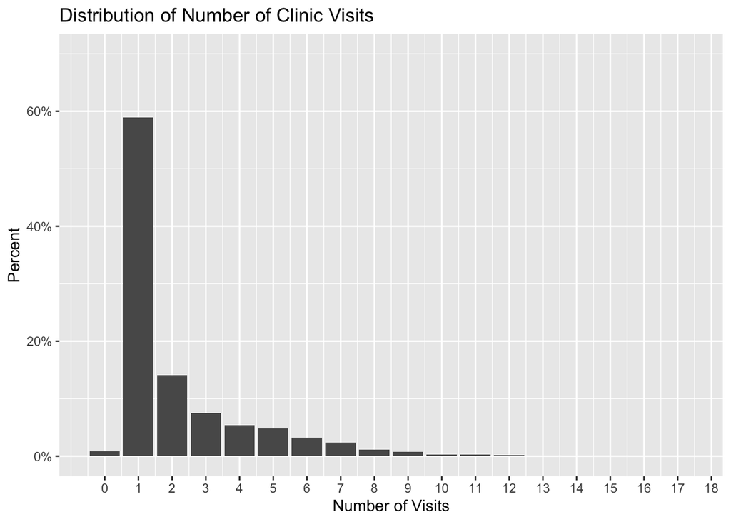

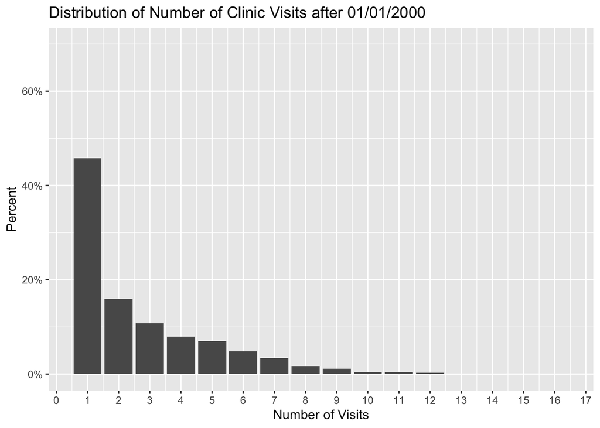

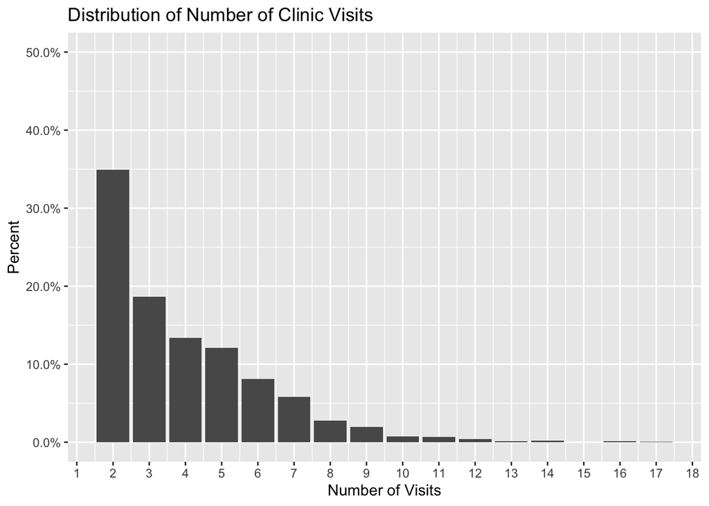

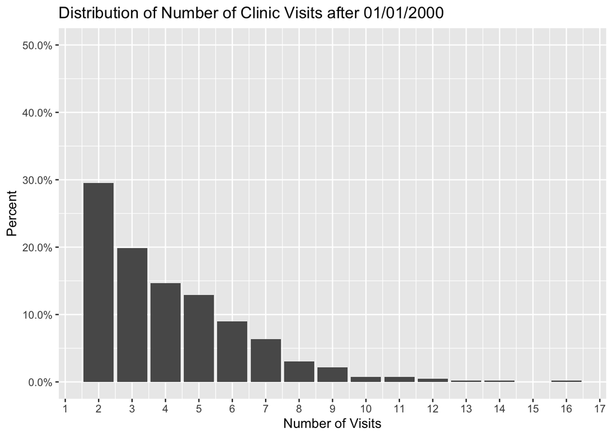

*First Clinic Date*

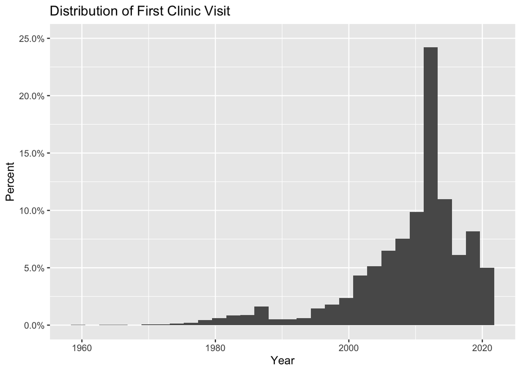

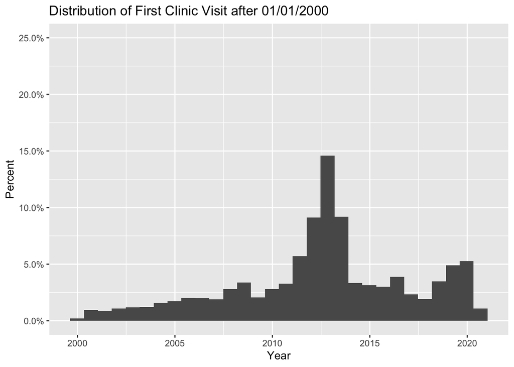

*Last Clinic Date*

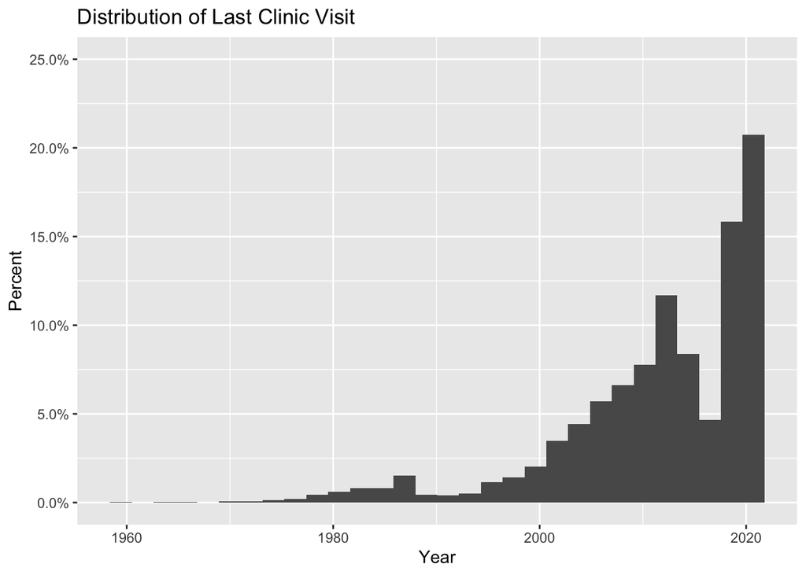

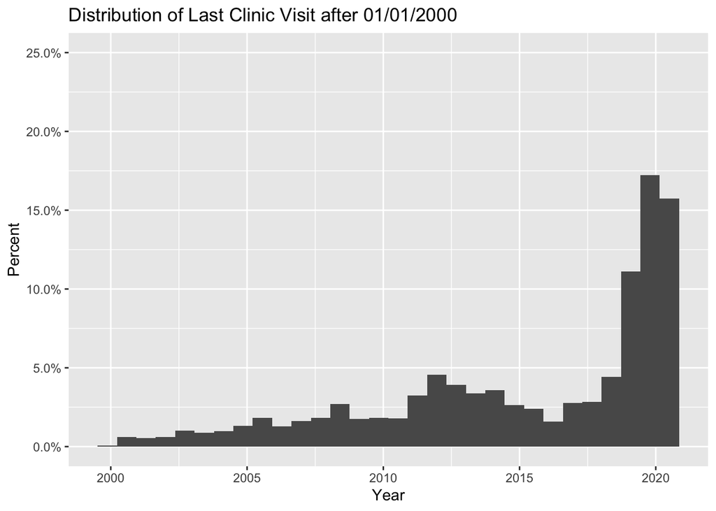

*Time between first and last clinic*

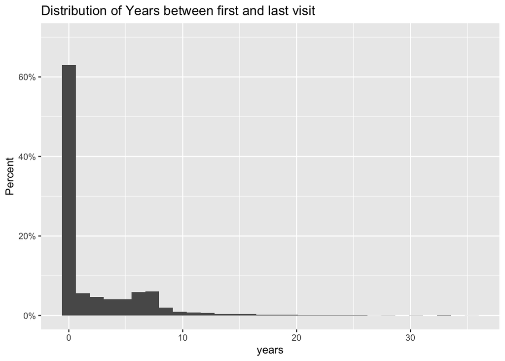

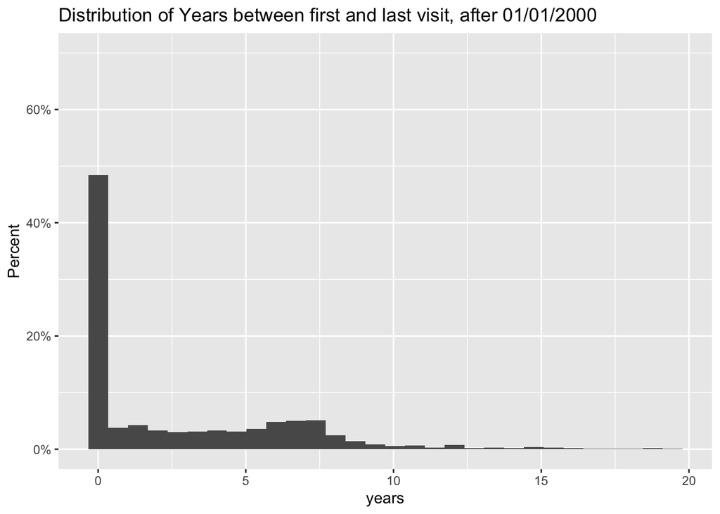

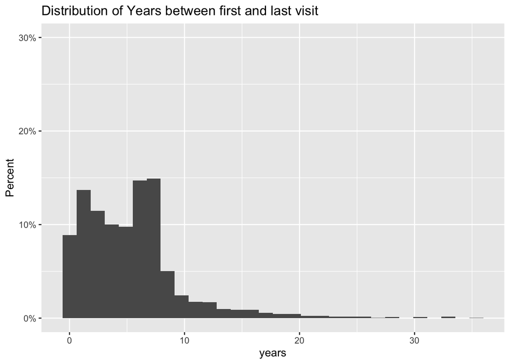

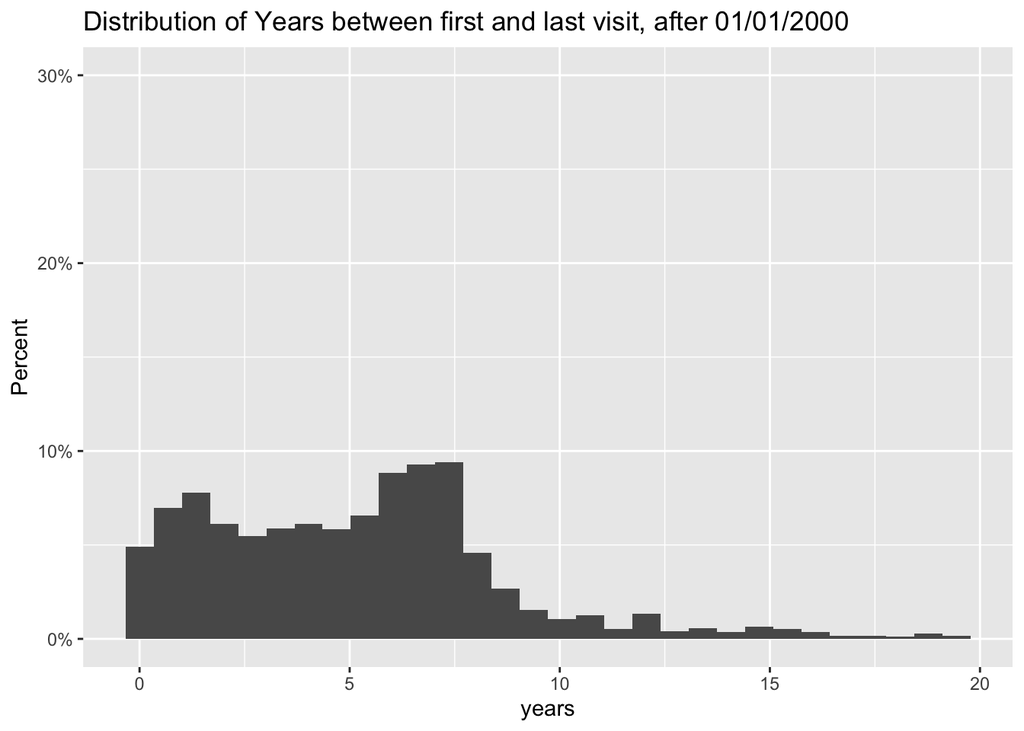

*sex*

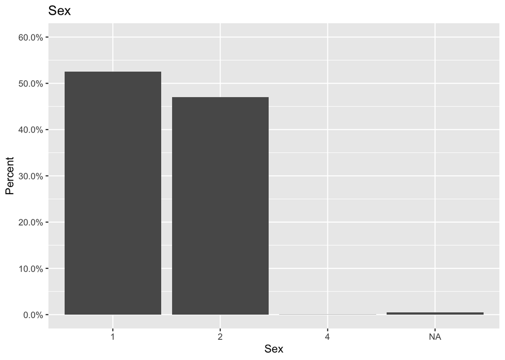

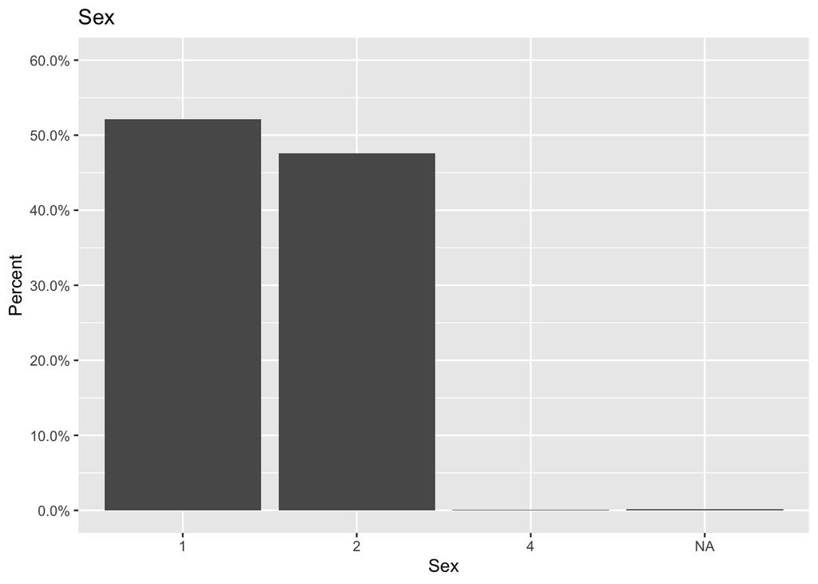

*age*

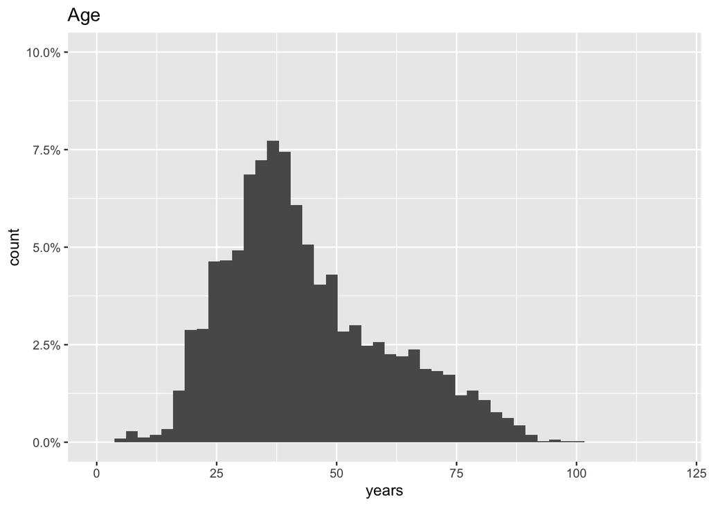

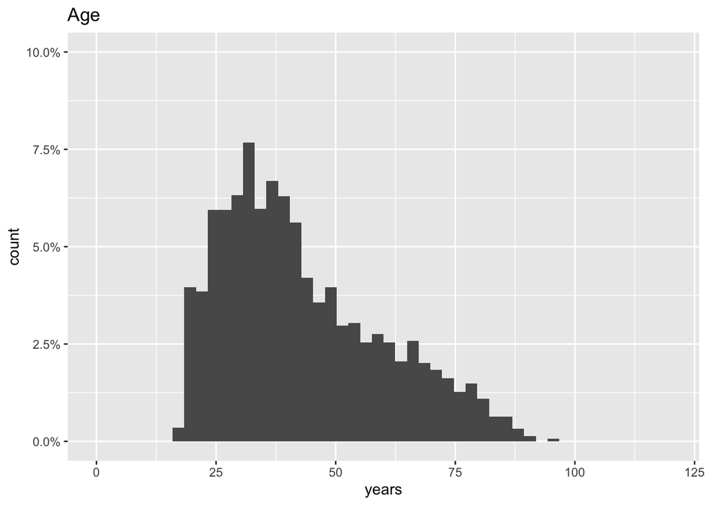

*death*

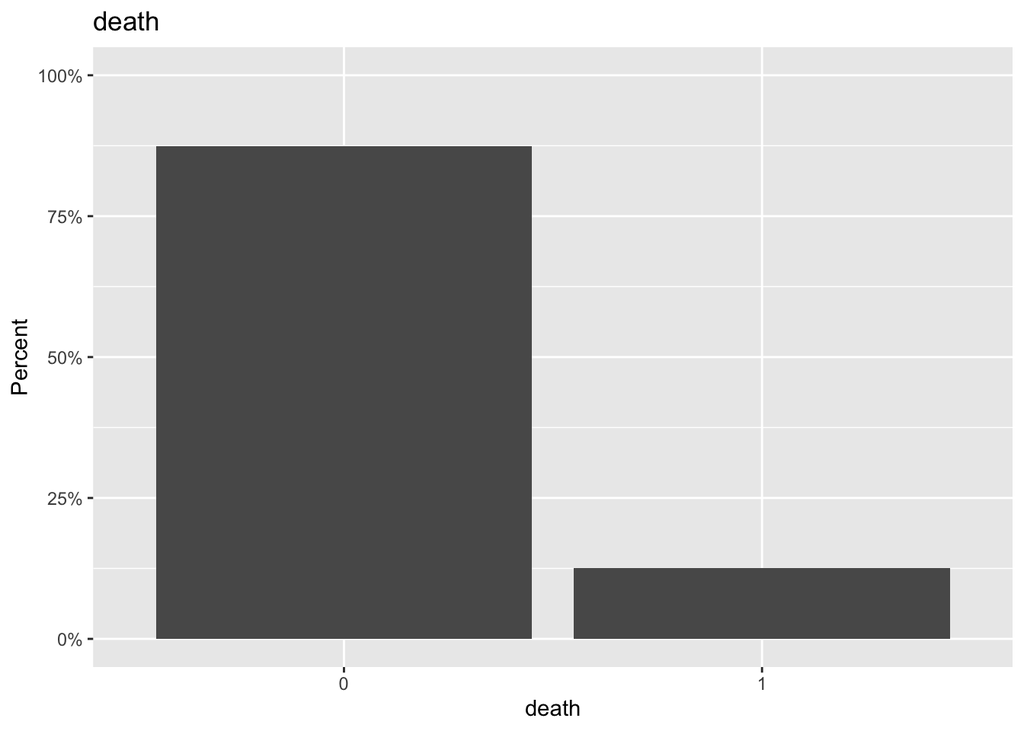

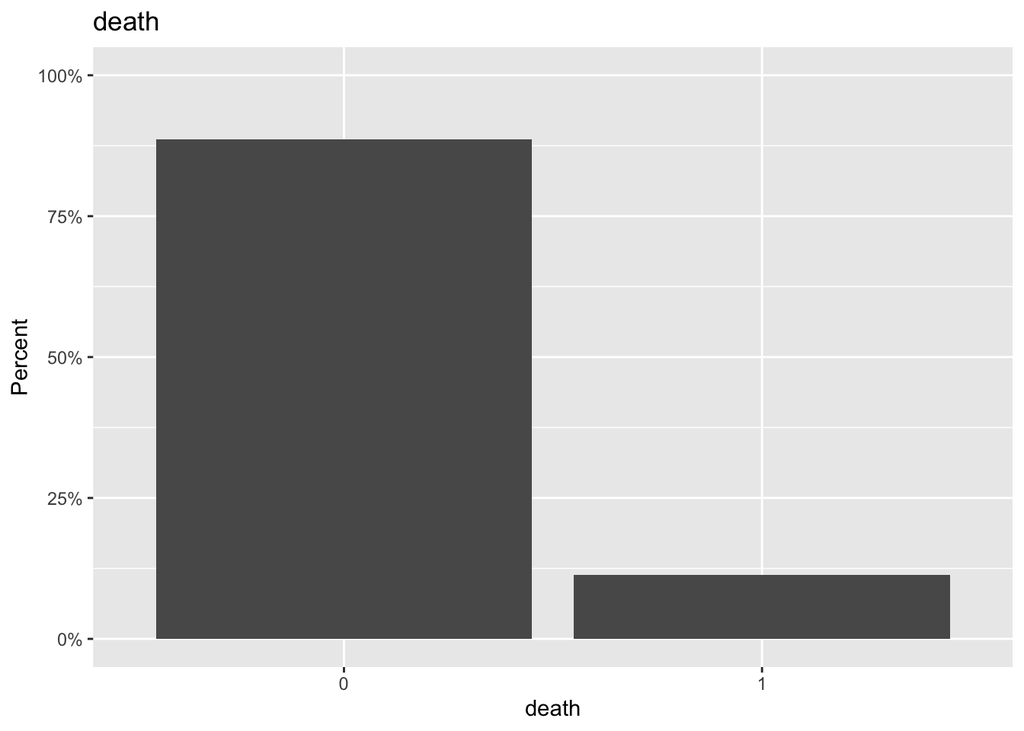

*age at death*

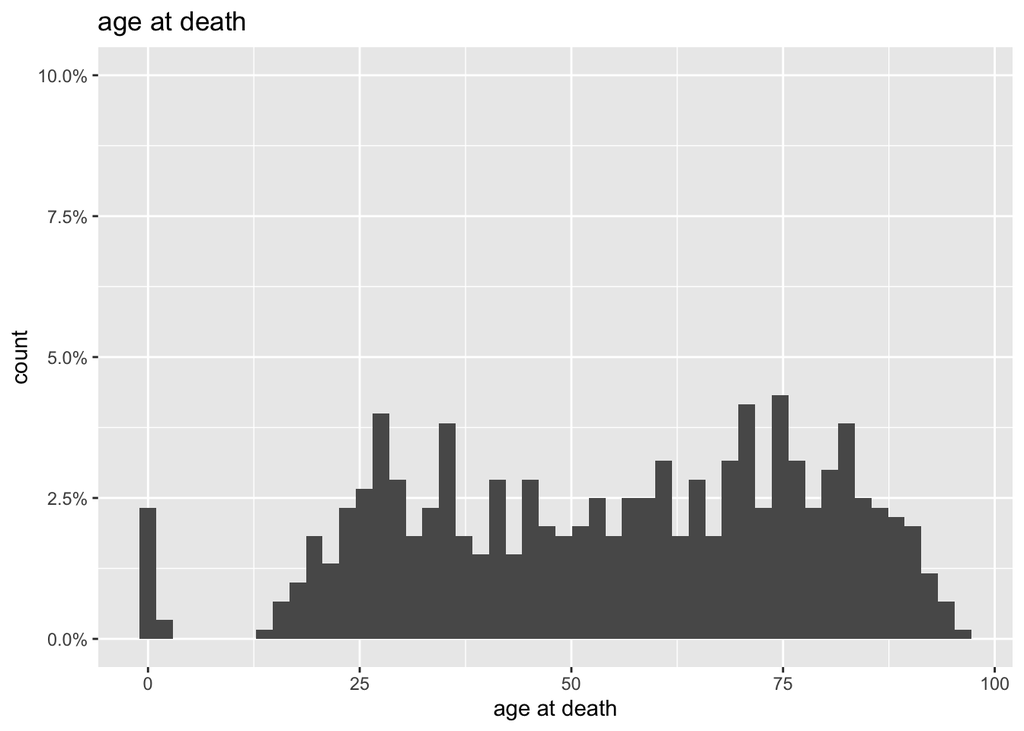

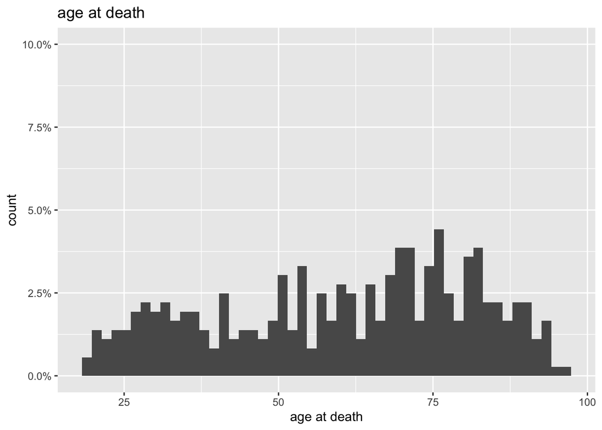

*Diagnoses*

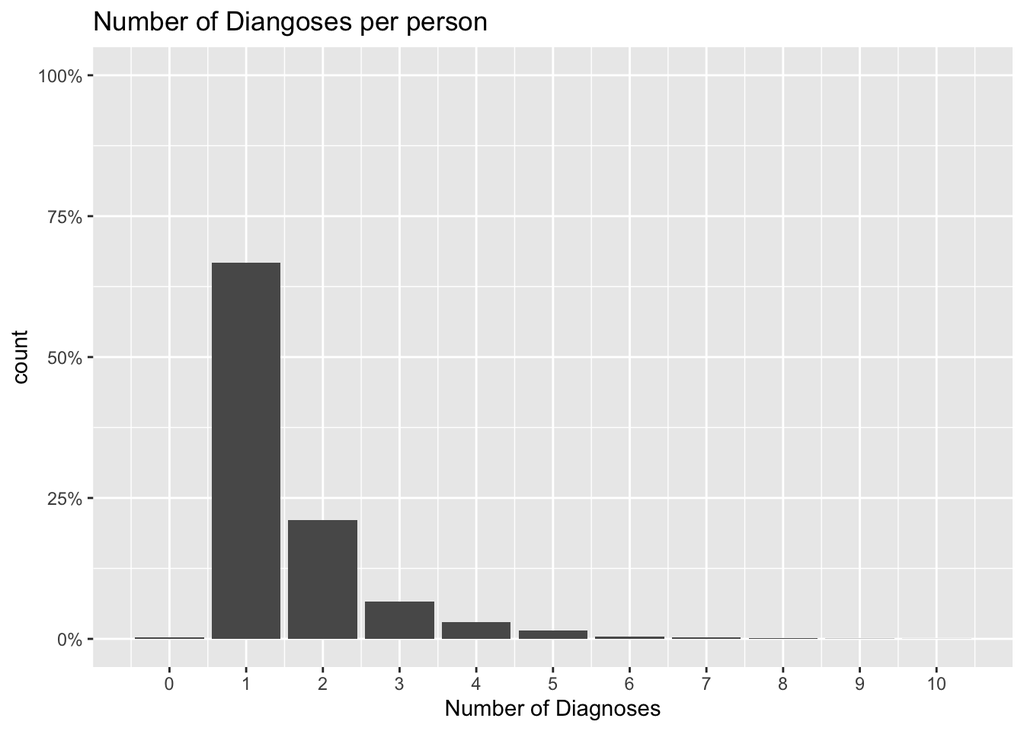

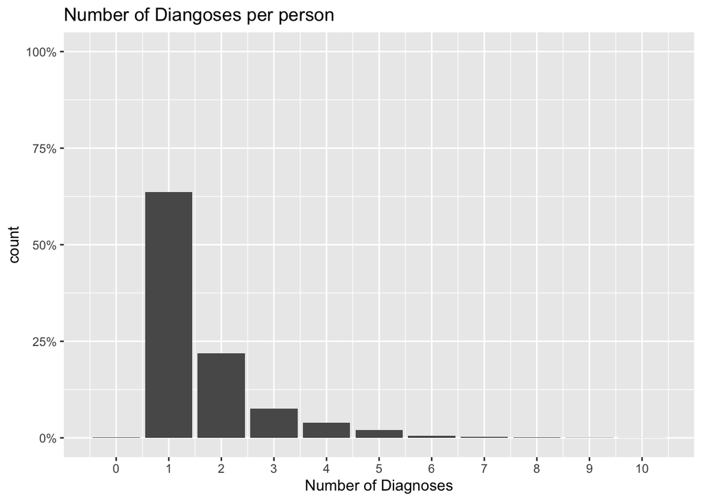

```
## [1] "number of people with no diagnosis - original dataset:"
```

```
## [1] 19
```

```
## [1] "number of people with no diagnosis - filtered dataset:"
```

```
## [1] 4
```

[output not shown]

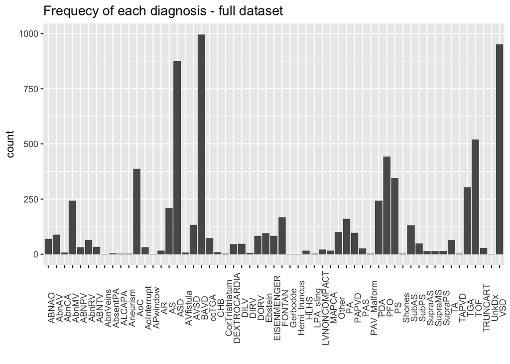

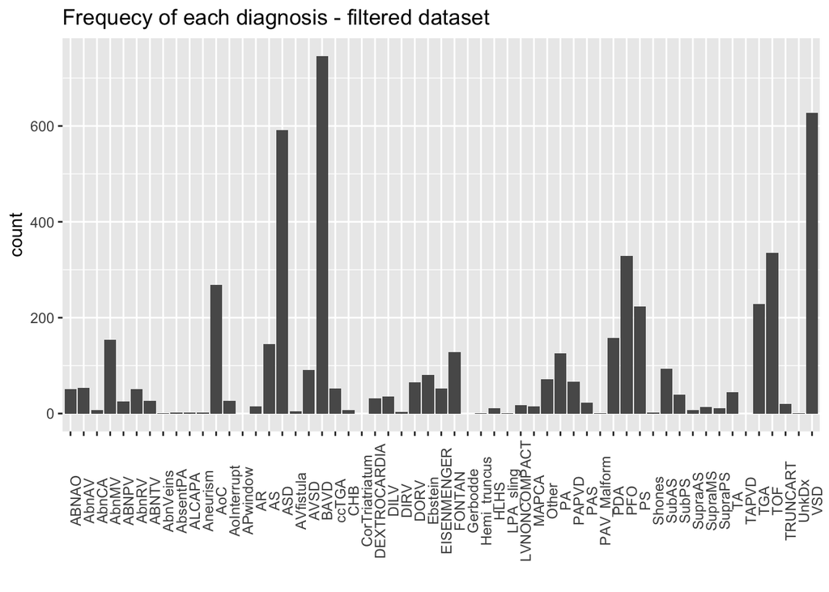

*Disease Severity*

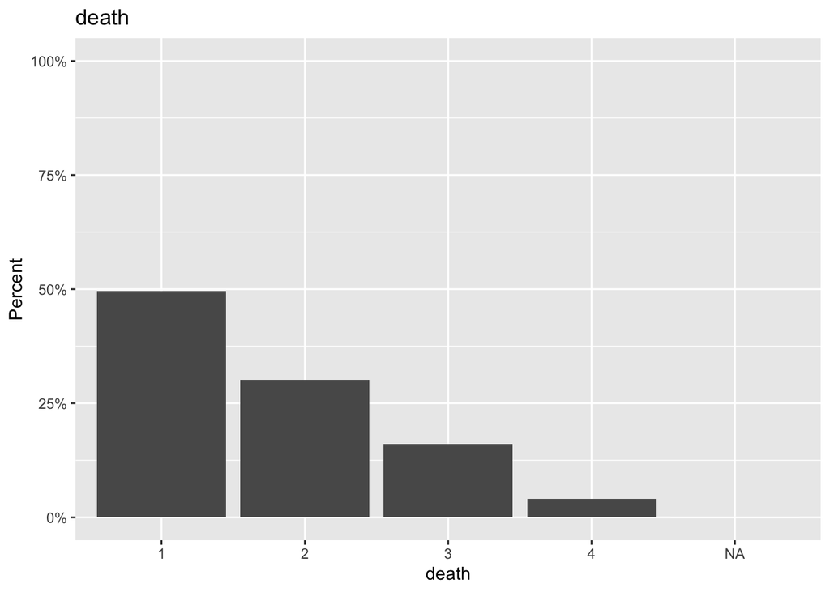

```r
ggplot(person.level, aes(x=bethesda_code)) +
  geom_bar(aes( y = ..count../sum(..count..)))+
  scale_y_continuous(limits = c(0,1), labels = percent) +
  labs(title = "death",
       y = "Percent",
       x = "death")
```

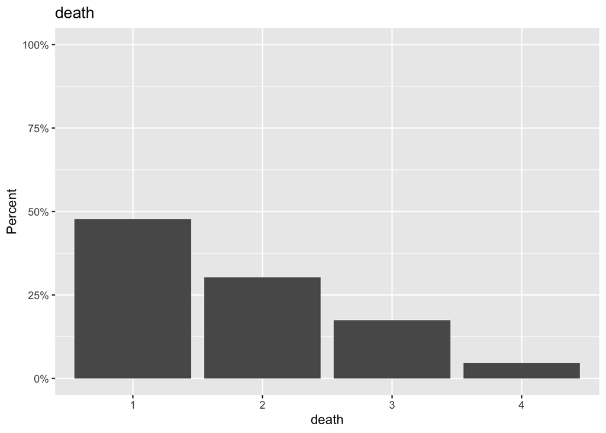

```r
ggplot(person.level.filtered, aes(x=bethesda_code)) +
  geom_bar(aes( y = ..count../sum(..count..)))+
  scale_y_continuous(limits = c(0,1), labels = percent) +
  labs(title = "death",
       y = "Percent",
       x = "death")
```

*Counting the ACHD population in each area*

```r
# count the number achd patients in each SA2 area
sa2.count <- person.level.filtered %>% count(sa2) %>%
                        rename("ACHD_count" = n)

# count the number achd patients in each SA3 area
sa3.count <- person.level.filtered %>% count(sa3) %>%
                        rename("ACHD_count" = n)

# count the number achd patients in each SA4 area
sa4.count <- person.level.filtered %>% count(sa4) %>%
                        rename("ACHD_count" = n)

# join the SA2 ACHD count with the area level (census data) dataset
area.df <- readRDS(file = "./development/EDA/output/sa2_table_builder.rds")
area.df.2 = left_join(area.df, sa2.count, by = c("sa2_area" = "sa2"))
```

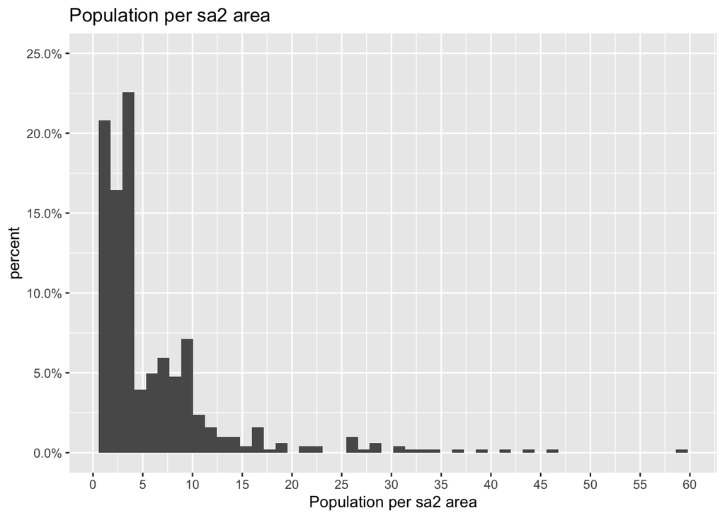

```r
sa2.count %>% filter(!is.na(sa2)) %>%
ggplot(aes(x=ACHD_count)) +
  geom_histogram(aes( y = ..count../sum(..count..)), bins = 50)+
  scale_y_continuous(limits = c(0,0.25), labels = percent) +
  scale_x_continuous(breaks = seq(0,60,5)) +
  labs(title = "Population per sa2 area",
       y = "percent",
       x = "Population per sa2 area")
```

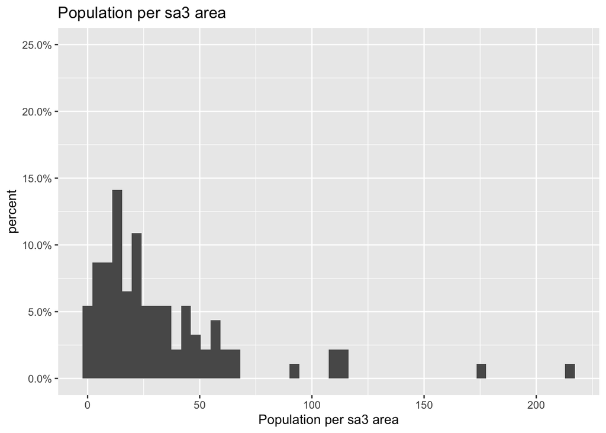

```r
sa3.count %>% filter(!is.na(sa3)) %>%
ggplot(aes(x=ACHD_count)) +
  geom_histogram(aes( y = ..count../sum(..count..)), bins = 50)+
  scale_y_continuous(limits = c(0,0.25), labels = percent) +
  scale_x_continuous(breaks = seq(0,500,50)) +
  labs(title = "Population per sa3 area",
       y = "percent",
       x = "Population per sa3 area")
```

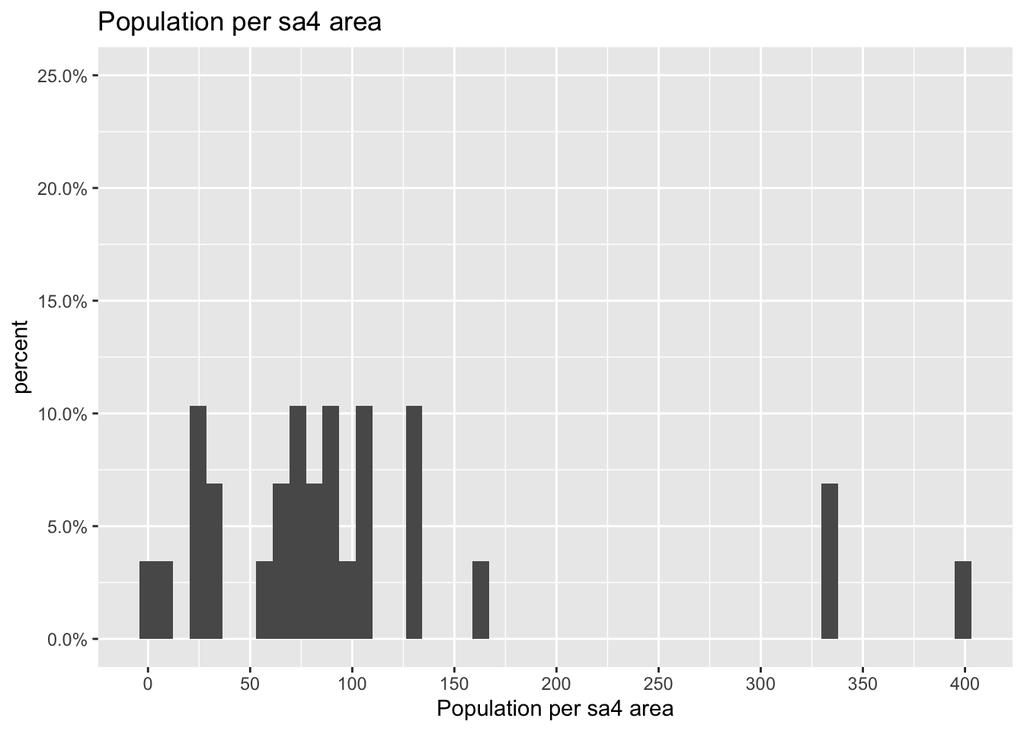

```r
sa4.count %>% filter(!is.na(sa4)) %>%
ggplot(aes(x=ACHD_count)) +
  geom_histogram(aes( y = ..count../sum(..count..)), bins = 50)+
  scale_y_continuous(limits = c(0,0.25), labels = percent) +
  scale_x_continuous(breaks = seq(0,500,50)) +
  labs(title = "Population per sa4 area",
       y = "percent",
       x = "Population per sa4 area")
```

*Saving the data*

```r
#Save the Master Code Sheet
library(xlsx)
# request a password to protect the master code sheet
mcs_pass <- readline(prompt="enter a password for the mastercode sheet: ")
# select the identifiers from the dataset
master_code_sheet <- person.level.filtered %>% select(achd_id, dob, sex, suburb, postcode, state)
# write the master code sheet to an excel spreadsheet
write.xlsx(x = master_code_sheet,
           file = paste(study_folder, 'master_code_sheet/RPAH_master_code_sheet_', Sys.Date(), '.xlsx', sep=""),
           sheetName = "master_code_sheet",
           password = mcs_pass)

#Save the analysis data set
analysis_dataset <- person.level.filtered %>% select(-dob, -suburb, -postcode, -state)
#write the analysis dataset to a csv file and an R data file
saveRDS(analysis_dataset, file = paste(study_folder, 'output/rpah_analysis_dataset_', Sys.Date(), '.rds', sep=""))
#cannot save the nested 'clinics columns as csv
analysis_dataset %>% select(-clinics,-clinics_2000) %>%
      write.csv(paste(study_folder, 'output/rpah_analysis_dataset_', Sys.Date(), '.csv', sep=""))

# Save the SA2 area level data with the ACHD count included
saveRDS(area.df.2, file = paste(study_folder, 'output/sa2_data_', Sys.Date(), '.rds', sep=""))
write.csv(area.df.2, paste(study_folder, 'output/sa2_data_', Sys.Date(), '.csv', sep=""))

# Save the SA2 area level data with the ACHD count included
saveRDS(sa2.count, file = paste(study_folder, 'output/sa2.count_', Sys.Date(), '.rds', sep=""))
write.csv(sa2.count, paste(study_folder, 'output/sa2.count_', Sys.Date(), '.csv', sep=""))

# Save the SA3 ACHD count
saveRDS(sa3.count, file = paste(study_folder, 'output/sa3.count_', Sys.Date(), '.rds', sep=""))
write.csv(sa3.count, paste(study_folder, 'output/sa3.count_', Sys.Date(), '.csv', sep=""))

# Save the SA4 ACHD count
saveRDS(sa4.count, file = paste(study_folder, 'output/sa4.count_', Sys.Date(), '.rds', sep=""))
write.csv(sa4.count, paste(study_folder, 'output/sa4.count_', Sys.Date(), '.csv', sep=""))
```